# Homework week 09

Daniel

2025-04-18

- Use the dominant copepod species data (from HW 1).
- Perform cluster analysis of stations based on percent composition data of the dominant species and tell your story about these copepod data.
- Compare the results based on different distance measures.
- Compare the results based on different cluster algorithms.
- Determine final number of clusters and describe the differences among them.

dominant species:

```r
#same as Hw01
setwd("C:/Users/dan91/Rstudio/statistic-in-ecology/stat_data/mock_dataTS")
cop_compo <- read.table("Copepod_composition.txt", header = T)
cop_den <- read.table("Cop_density.txt")
cop_sp <- read.table("copepodSPlist.txt", fill = T, sep = "\n")

sp_den <- matrix(0, nrow = length(cop_sp$V1), ncol = length(cop_den$V1))
for(i in 1:length(cop_sp$V1)){
  for(j in 1:length(cop_den$V1)){
    sp_den[i, j] <- cop_compo[i, j]/100 * cop_den[j,]
  }
}
sp_den.df <- as.data.frame(sp_den)
colnames(sp_den.df) <- colnames(cop_compo)
rownames(sp_den.df) <- cop_sp$V1
head(sp_den.df)
```

```
##                    X.p1 p3 p4 p6 p13    p16     p19 p21     p23    p25      s18
## Acartia bifilosa      0  0  0  0   0 0.0000  0.0000   0  0.0000  0.000   0.0000
## Acartia erythraea     0  0  0  0   0 0.0000  0.0000   0  0.0000  0.000   0.0000
## Acartia negligence    0  0  0  0   0 4.6706 27.1206   0 33.9101 15.552   0.0000
## Acartia omori         0  0  0  0   0 0.0000  0.0000   0  0.0000  0.000   0.0000
## Acartia pacifica      0  0  0  0   0 0.0000  0.0000   0  0.0000  0.000 119.9022
## Acartia sp            0  0  0  0   0 0.0000  0.0000   0  0.0000  0.000   0.0000
##                      s19     s20      s22      s23     s25     s27     s29
## Acartia bifilosa    0.00  0.0000   0.0000   0.0000 18.9960  0.0000  0.0000
## Acartia erythraea   0.00  0.0000   0.0000   0.0000  0.0000  0.0000  0.0000
## Acartia negligence  0.00  0.0000   0.0000   0.0000  0.0000 31.9352 14.4690
## Acartia omori       0.00  0.0000   0.0000   0.0000  0.0000  0.0000  0.0000
## Acartia pacifica   29.64 16.2864 195.2769 417.6231 94.3468  0.0000  0.0000
## Acartia sp          0.00  0.0000   0.0000   0.0000  0.0000 15.9676 72.8273
##                         sA      sB     sC     sD       sE       sF    sG
## Acartia bifilosa    0.0000  0.0000  0.000 0.0000   0.0000   0.0000  0.00
## Acartia erythraea   0.0000  0.0000  0.000 0.0000   0.0000   0.0000  0.00
## Acartia negligence 48.5928 39.0825 47.988 8.3948 160.3664  24.5458 17.78
## Acartia omori       4.1288  0.0000  0.000 0.0000   0.0000   0.0000  0.00
## Acartia pacifica    4.1288  0.0000  0.000 0.0000  17.5744 121.1454  0.00
## Acartia sp          0.0000  0.0000  0.000 0.0000   0.0000   0.0000  0.00
##                         w22      w23      w25     w27      w29      wA      wB
## Acartia bifilosa    0.00000   0.0000 0.000000 0.00000 0.000000 0.00000 0.00000
## Acartia erythraea   0.00000   0.0000 0.000000 0.00000 0.175308 0.00000 0.00000
## Acartia negligence  0.00000   0.0000 0.000000 0.00000 0.000000 0.00000 1.10334
## Acartia omori       0.00000   0.0000 0.000000 0.00000 0.000000 0.00000 0.00000
## Acartia pacifica   69.54302 135.4973 2.266827 1.77331 2.621272 0.05093 0.13916
## Acartia sp          0.00000   0.0000 0.000000 0.00000 0.000000 0.00000 0.00000
##                          wC       wD
## Acartia bifilosa   0.000000 0.000000
## Acartia erythraea  0.000000 0.000000
## Acartia negligence 0.290862 0.434031
## Acartia omori      0.000000 0.000000
## Acartia pacifica   0.000000 0.289354
## Acartia sp         0.000000 0.000000
```

```r
dominant_sp.df <- data.frame(ifelse(cop_compo >= 5, 1, 0))
dominant_species <- rownames(dominant_sp.df)[rowSums(dominant_sp.df) >= 1]
as.numeric(dominant_species)
```

```
##  [1]   5  14  15  35  40  51  54  60  72  79  84  85  86  88 106 112 117 118 123
## [20] 126 135 142 145 147 161 164 169
```

```r
dom_sp_compo <- t(cop_compo[dominant_species, ]) #exchange x-axis and y-axis to compare with different cruise station
colnames(dom_sp_compo) <- cop_sp[dominant_species, ] #change the column names into dominant species names
rownames(dom_sp_compo) <- colnames(cop_compo)
```

```r
library(vegan)
library(cluster)
```

Comparing with four different distance measures

1. Euclidean

```r
dist_eu <- dist(dom_sp_compo, "euclidean")

hc_eu_average <- hclust(dist_eu, "average") #use the hclust function to make hierarchical cluster by average method
hc_eu_ward <- hclust(dist_eu, "ward.D2") #by modified ward method

par(mfrow=c(1,2))

plot(hc_eu_average, main = "Euclidean + Average")
cutree(hc_eu_average, k = 8) #manually determine into 8 clusters
```

```
## X.p1   p3   p4   p6  p13  p16  p19  p21  p23  p25  s18  s19  s20  s22  s23  s25
##    1    2    2    2    3    2    3    3    4    3    4    4    4    4    4    4
##  s27  s29   sA   sB   sC   sD   sE   sF   sG  w22  w23  w25  w27  w29   wA   wB
##    5    5    4    4    4    4    4    4    5    6    7    6    6    3    8    8
##   wC   wD
##    8    8
```

```r
rect.hclust(hc_eu_average, k = 8) #plot the number of clusters on the hierarchical cluster

plot(hc_eu_ward, main = "Euclidean + Ward")
cutree(hc_eu_ward, k = 3)
```

```
## X.p1   p3   p4   p6  p13  p16  p19  p21  p23  p25  s18  s19  s20  s22  s23  s25
##    1    1    1    1    1    1    1    1    1    1    1    1    2    2    2    2
##  s27  s29   sA   sB   sC   sD   sE   sF   sG  w22  w23  w25  w27  w29   wA   wB
##    2    2    2    2    2    2    2    2    2    3    3    3    3    1    3    3
##   wC   wD
##    3    3
```

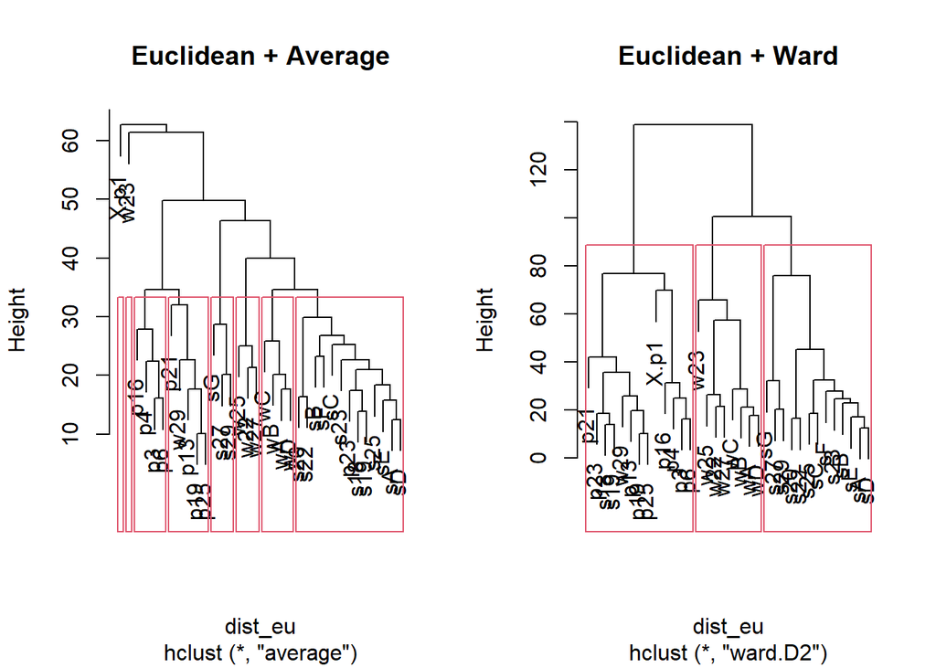

```r
rect.hclust(hc_eu_ward, k = 3)
```

2. Manhattan

```r
# same as above
dist_man <- dist(dom_sp_compo, "manhattan")

hc_man_average <- hclust(dist_man, "average")
hc_man_ward <- hclust(dist_man, "ward.D2")

par(mfrow=c(1,2))

plot(hc_man_average, main = "Manhattan + Average")
cutree(hc_man_average, k = 3)
```

```
## X.p1   p3   p4   p6  p13  p16  p19  p21  p23  p25  s18  s19  s20  s22  s23  s25
##    1    1    1    1    1    1    1    1    1    1    2    2    2    2    2    2
##  s27  s29   sA   sB   sC   sD   sE   sF   sG  w22  w23  w25  w27  w29   wA   wB
##    2    2    2    2    2    2    2    2    2    3    3    3    3    3    3    3
##   wC   wD
##    3    3
```

```r
rect.hclust(hc_man_average, k = 3)

plot(hc_man_ward, main = "Manhattan + Ward")
cutree(hc_man_ward, k = 3)
```

```
## X.p1   p3   p4   p6  p13  p16  p19  p21  p23  p25  s18  s19  s20  s22  s23  s25
##    1    1    1    1    1    1    1    1    1    1    2    2    2    2    2    2
##  s27  s29   sA   sB   sC   sD   sE   sF   sG  w22  w23  w25  w27  w29   wA   wB
##    2    2    2    2    2    2    2    2    2    3    3    3    3    3    3    3
##   wC   wD
##    3    3
```

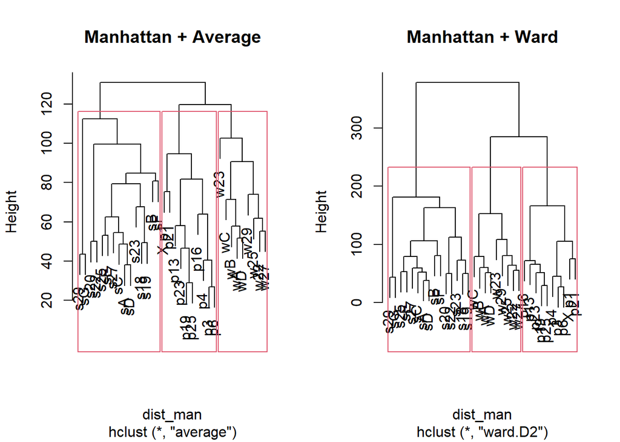

```r
rect.hclust(hc_man_ward, k = 3)
```

3. Bray-Crutis

```r
dist_bc <- vegdist(dom_sp_compo, "bray")

hc_bc_average <- hclust(dist_bc, "average")
hc_bc_ward <- hclust(dist_bc, "ward.D2")

par(mfrow=c(1,2))

plot(hc_bc_average, main = "Bray-Curtis + Average")
cutree(hc_bc_average, k = 3)
```

```
## X.p1   p3   p4   p6  p13  p16  p19  p21  p23  p25  s18  s19  s20  s22  s23  s25
##    1    1    1    1    1    1    1    1    1    1    2    2    2    2    2    2
##  s27  s29   sA   sB   sC   sD   sE   sF   sG  w22  w23  w25  w27  w29   wA   wB
##    2    2    2    2    2    2    2    2    2    3    3    3    3    3    3    3
##   wC   wD
##    3    3
```

```r
rect.hclust(hc_bc_average, k = 3)

plot(hc_bc_ward, main = "Bray-Curtis + Ward")
cutree(hc_bc_ward, k = 3)
```

```
## X.p1   p3   p4   p6  p13  p16  p19  p21  p23  p25  s18  s19  s20  s22  s23  s25
##    1    1    1    1    1    1    1    1    1    1    2    2    2    2    2    2
##  s27  s29   sA   sB   sC   sD   sE   sF   sG  w22  w23  w25  w27  w29   wA   wB
##    2    2    2    2    2    2    2    2    2    3    3    3    3    3    3    3
##   wC   wD
##    3    3
```

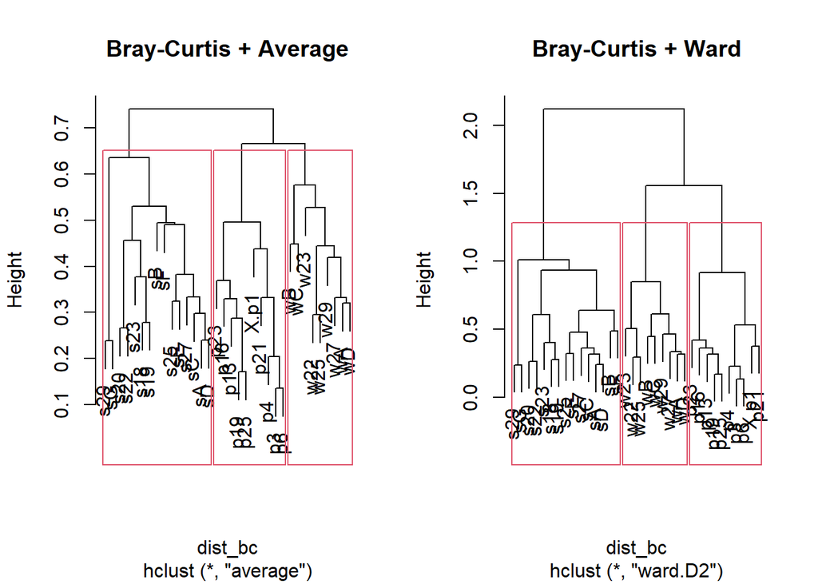

```r
rect.hclust(hc_bc_ward, k = 3)
```

4. Jaccard

```r
dist_ja <- vegdist(dom_sp_compo, "jaccard", binary = T)

hc_ja_average <- hclust(dist_ja, "average")
hc_ja_complete <- hclust(dist_ja, "complete")

par(mfrow=c(1,2))

plot(hc_ja_average, main = "Jaccard + Average")
cutree(hc_ja_average, k = 4)
```

```
## X.p1   p3   p4   p6  p13  p16  p19  p21  p23  p25  s18  s19  s20  s22  s23  s25
##    1    1    1    1    2    2    2    1    2    2    3    3    3    3    3    3
##  s27  s29   sA   sB   sC   sD   sE   sF   sG  w22  w23  w25  w27  w29   wA   wB
##    3    3    3    3    3    3    3    3    3    4    4    4    4    4    4    4
##   wC   wD
##    4    4
```

```r
rect.hclust(hc_ja_average, k = 4)

plot(hc_ja_complete, main = "Jaccard + Complete")
cutree(hc_ja_complete, k = 4)
```

```
## X.p1   p3   p4   p6  p13  p16  p19  p21  p23  p25  s18  s19  s20  s22  s23  s25
##    1    1    1    1    2    2    2    1    2    2    3    3    3    3    3    3
##  s27  s29   sA   sB   sC   sD   sE   sF   sG  w22  w23  w25  w27  w29   wA   wB
##    3    3    3    3    3    3    3    3    3    4    4    4    4    4    4    4
##   wC   wD
##    4    4
```

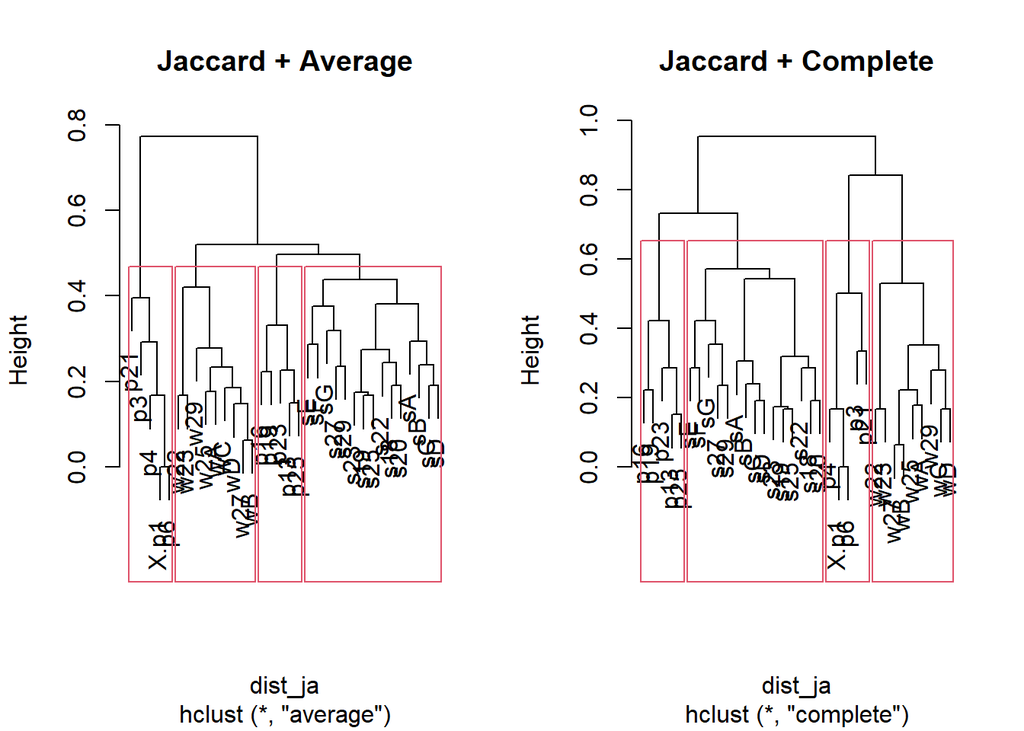

```r
rect.hclust(hc_ja_complete, k = 4)
```

```r
distance <- c("Euclidean", "Manhattan", "Bray-Curtis", "Jaccard")
k_average <- c(8, 3, 3, 4)
k_ward <- c(3, 3, 3, NA)
k_complete <- c(NA, NA, NA, 4)
k_compare <- data.frame(distance, k_average, k_ward, k_complete)
k_compare
```

```
##      distance k_average k_ward k_complete
## 1   Euclidean         8      3         NA
## 2   Manhattan         3      3         NA
## 3 Bray-Curtis         3      3         NA
## 4     Jaccard         4     NA          4
```

Cophenetic Correlation

```r
coph_eu_average <- round(cor(cophenetic(hc_eu_average), dist_eu), 3)
coph_eu_ward <- round(cor(cophenetic(hc_eu_ward), dist_eu), 3)
coph_man_average <- round(cor(cophenetic(hc_man_average), dist_man), 3)
coph_man_ward <- round(cor(cophenetic(hc_man_ward), dist_man), 3)
coph_bc_average <- round(cor(cophenetic(hc_bc_average), dist_bc), 3)
coph_bc_ward <- round(cor(cophenetic(hc_bc_ward), dist_bc), 3)
coph_ja_average <- round(cor(cophenetic(hc_ja_average), dist_ja), 3)
coph_ja_complete <- round(cor(cophenetic(hc_ja_complete), dist_ja), 3)
```

```r
distance <- c("Euclidean", "Manhattan", "Bray-Curtis", "Jaccard")
coph_average <- c(coph_eu_average, coph_man_average, coph_bc_average, coph_ja_average)
coph_ward <- c(coph_eu_ward, coph_man_ward, coph_bc_ward, NA)
coph_complete <- c(NA, NA, NA, coph_ja_complete)
cop_compare <- data.frame(distance, coph_average, coph_ward, coph_complete)
cop_compare
```

```
##      distance coph_average coph_ward coph_complete
## 1   Euclidean        0.736     0.509            NA
## 2   Manhattan        0.709     0.674            NA
## 3 Bray-Curtis        0.754     0.718            NA
## 4     Jaccard        0.880        NA         0.685
```

non-Hierarchical

1. Euclidean

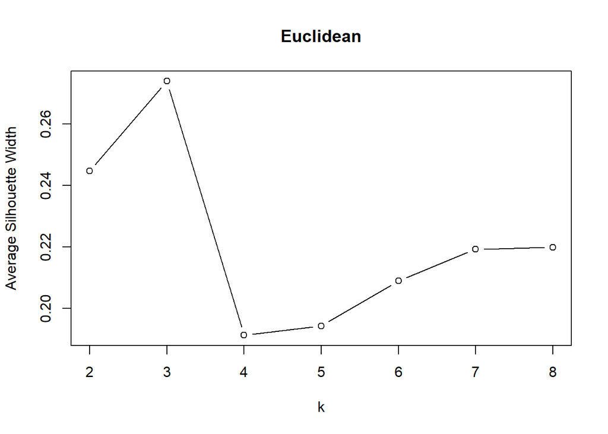

```r
sil_eu <- sapply(2:8, function(k){ #testing different k from 2 to 8
  pam_eu <- pam(dist_eu, k)
  pam_eu$silinfo$avg.width #showing average silhouette width of 2 clusters to 8 clusters
})

par(mfrow=c(1,1))
plot(2:8, sil_eu, type = "b", #plot the average silhouette width to find the best number of clusters
     xlab = "k",
     ylab = "Average Silhouette Width",
     main = "Euclidean")
```

```r
pam_eu_best <- pam(dist_eu, k = 3)
pam_eu_best$clustering #showing all the stations belong to which cluster
```

```
## X.p1   p3   p4   p6  p13  p16  p19  p21  p23  p25  s18  s19  s20  s22  s23  s25
##    1    1    1    1    1    1    1    1    2    1    2    2    2    2    2    2
##  s27  s29   sA   sB   sC   sD   sE   sF   sG  w22  w23  w25  w27  w29   wA   wB
##    2    2    2    2    2    2    2    2    2    3    3    3    3    3    3    3
##   wC   wD
##    2    3
```

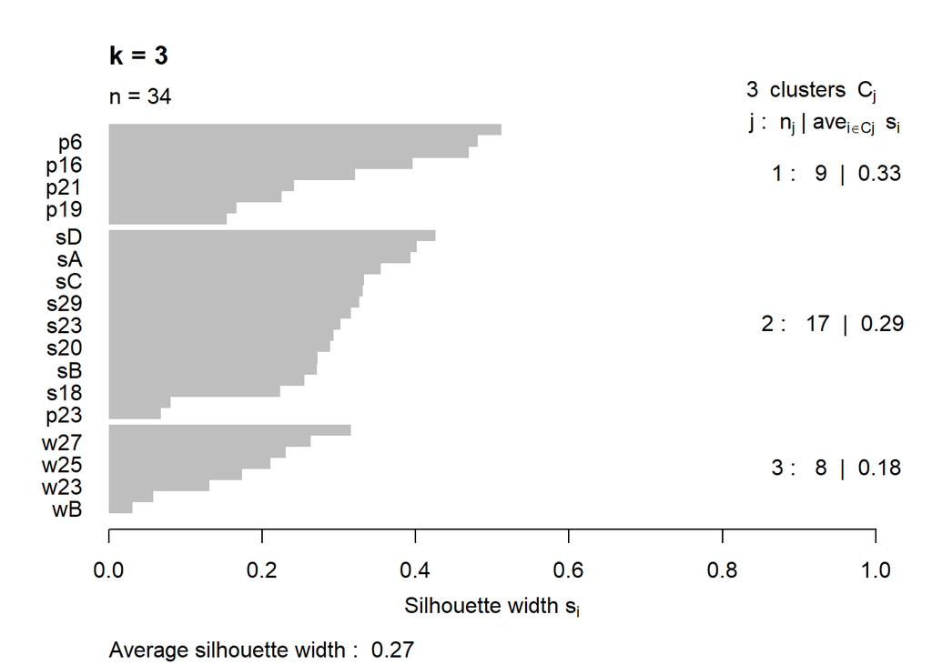

```r
plot(silhouette(pam_eu_best), border = NA, main = "k = 3") #separate those stations into three clusters
```

2. Manhattan

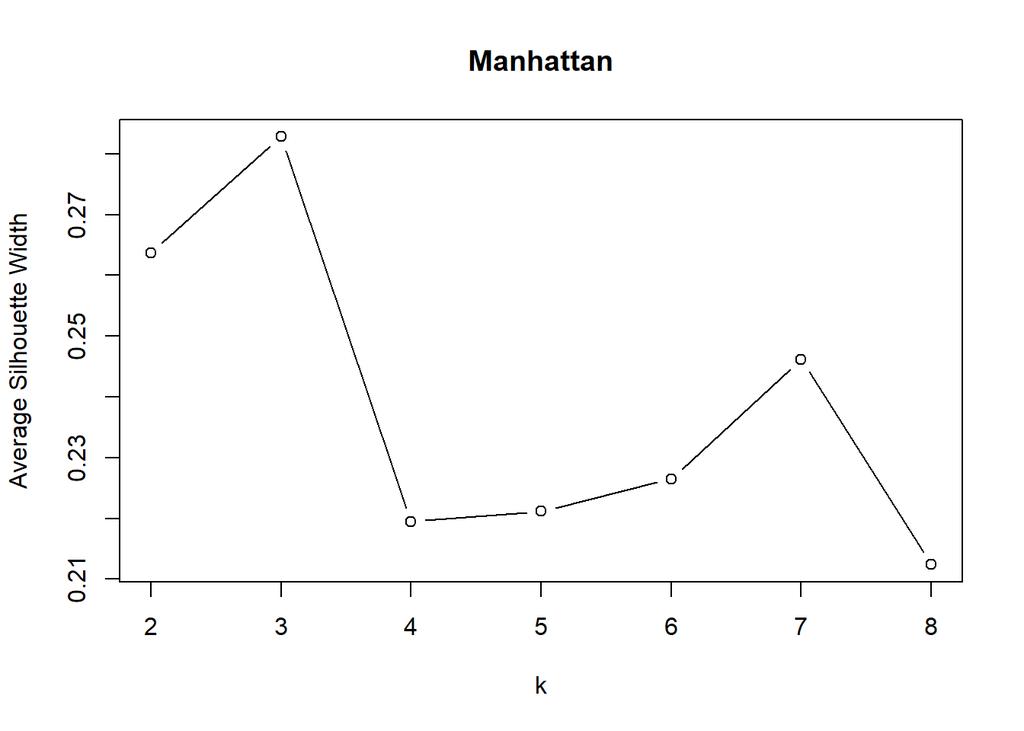

```r
sil_man <- sapply(2:8, function(k){
  pam_man <- pam(dist_man, k)
  pam_man$silinfo$avg.width
})

par(mfrow=c(1,1))
plot(2:8, sil_man, type = "b",
     xlab = "k",
     ylab = "Average Silhouette Width",
     main = "Manhattan")
```

```r
pam_man_best <- pam(dist_man, k = 3)
pam_man_best$clustering
```

```
## X.p1   p3   p4   p6  p13  p16  p19  p21  p23  p25  s18  s19  s20  s22  s23  s25
##    1    1    1    1    1    1    1    1    2    1    3    3    3    3    3    3
##  s27  s29   sA   sB   sC   sD   sE   sF   sG  w22  w23  w25  w27  w29   wA   wB
##    3    3    3    3    3    3    3    3    3    2    2    2    2    2    2    2
##   wC   wD
##    3    2
```

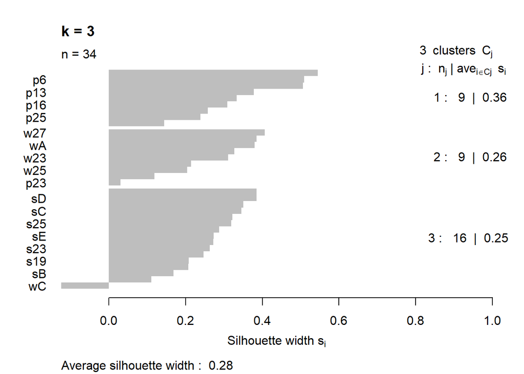

```r
plot(silhouette(pam_man_best), border = NA, main = "k = 3")
```

3. Bray-Crutis

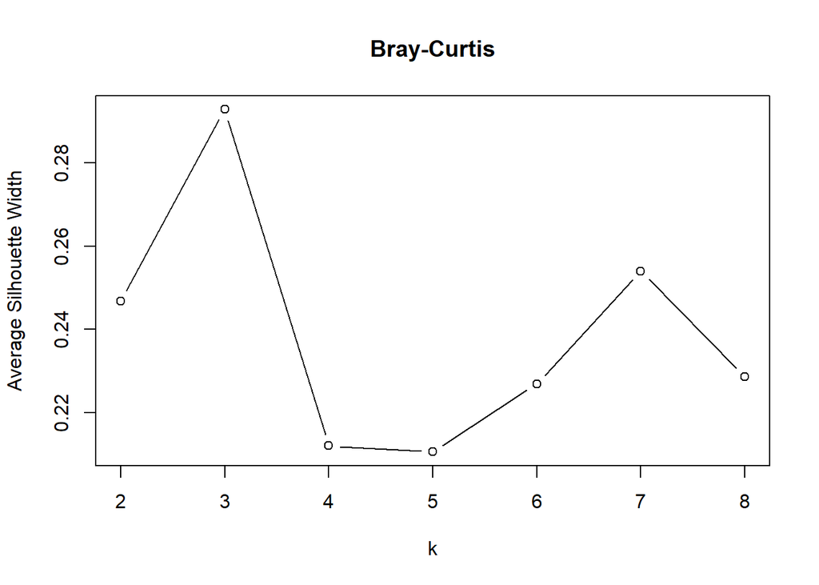

```r
sil_bc <- sapply(2:8, function(k){
  pam_bc <- pam(dist_bc, k)
  pam_bc$silinfo$avg.width
})

par(mfrow=c(1,1))
plot(2:8, sil_bc, type = "b",
     xlab = "k",
     ylab = "Average Silhouette Width",
     main = "Bray-Curtis")
```

```r
pam_bc_best <- pam(dist_bc, k = 3)
pam_bc_best$clustering
```

```
## X.p1   p3   p4   p6  p13  p16  p19  p21  p23  p25  s18  s19  s20  s22  s23  s25
##    1    1    1    1    1    1    1    1    2    1    3    3    3    3    3    3
##  s27  s29   sA   sB   sC   sD   sE   sF   sG  w22  w23  w25  w27  w29   wA   wB
##    3    3    3    3    3    3    3    3    3    2    2    2    2    2    2    2
##   wC   wD
##    2    2
```

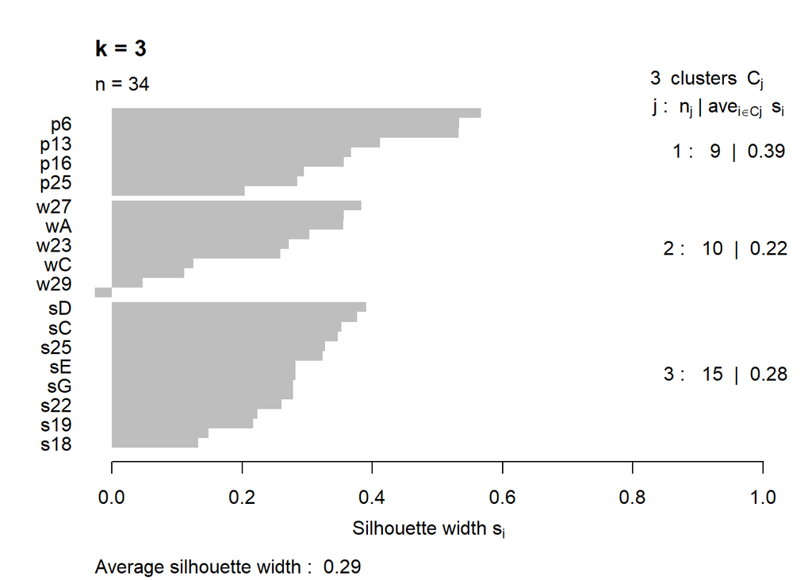

```r
plot(silhouette(pam_bc_best), border = NA, main = "k = 3")
```

4. Jaccard

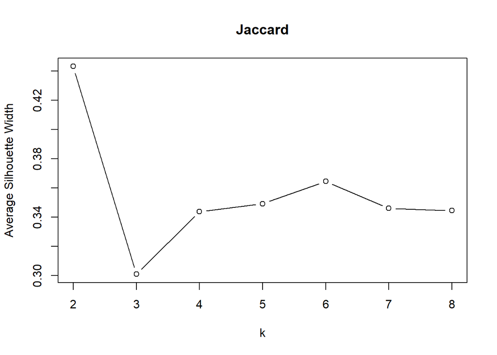

```r
sil_ja <- sapply(2:8, function(k){
  pam_ja <- pam(dist_ja, k)
  pam_ja$silinfo$avg.width
})

par(mfrow=c(1,1))
plot(2:8, sil_ja, type = "b",
     xlab = "k",
     ylab = "Average Silhouette Width",
     main = "Jaccard")
```

```r
pam_ja_best <- pam(dist_ja, k = 2)
pam_ja_best$clustering
```

```
## X.p1   p3   p4   p6  p13  p16  p19  p21  p23  p25  s18  s19  s20  s22  s23  s25
##    1    1    1    1    2    2    2    1    2    2    2    2    2    2    2    2
##  s27  s29   sA   sB   sC   sD   sE   sF   sG  w22  w23  w25  w27  w29   wA   wB
##    2    2    2    2    2    2    2    2    2    2    2    2    2    2    2    2
##   wC   wD
##    2    2
```

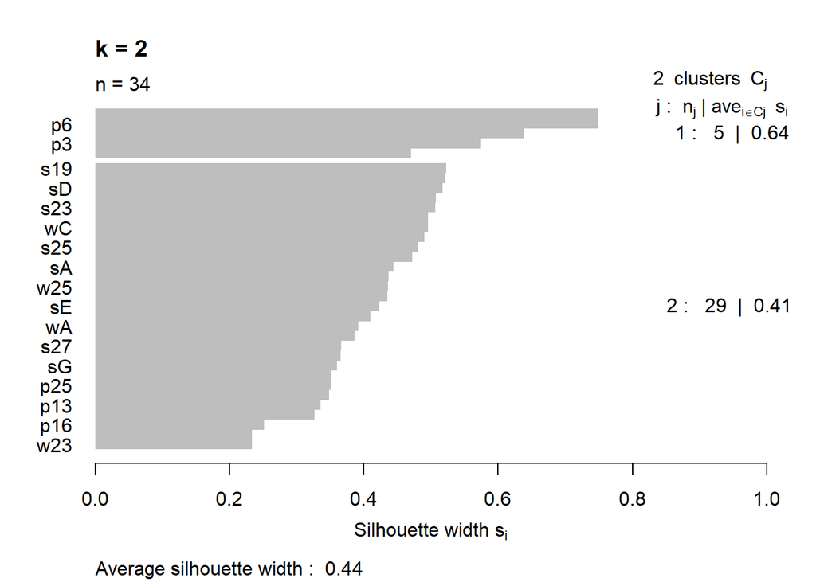

```r
plot(silhouette(pam_ja_best), border = NA, main = "k = 2")
```

```r
distance <- c("Euclidean", "Manhattan", "Bray-Curtis", "Jaccard")
best_k <- c(3, 3, 3, 2)
average_silhouette <- c(0.27, 0.28, 0.29, 0.44)
compare <- data.frame(distance, best_k, average_silhouette)
compare
```

```
##      distance best_k average_silhouette
## 1   Euclidean      3               0.27
## 2   Manhattan      3               0.28
## 3 Bray-Curtis      3               0.29
## 4     Jaccard      2               0.44
```

1. From k_compare, Euclidean + average linkage resulted in a chaining pattern, leading to the choice of 8 clusters, which contrasts with the more consistent 3-cluster solutions from Ward linkage across Euclidean, Manhattan, and Bray-Curtis distances.
2. Form cop_compare, the dendrogram constructed using average linkage based on Jaccard distance most faithfully preserved the original dissimilarity structure.
3. From “compare”, Jaccard distance (binary) performed best with an average silhouette width of 0.44 when using 2 clusters.
- In contrast, abundance-based distances such as Bray-Curtis, Manhattan, and Euclidean all selected 3 clusters but had significantly lower silhouette values (0.27–0.29), suggesting weaker group separation.
- This result indicates that presence/absence differences among stations may be more important than fine-scale abundance variation in structuring the copepod community across seasons.